# Visualizing the bootstrap process

Christopher Gatti

December 7, 2017

```r
library(animation)
library(Rmdanimation)
ani.options(convert = 'c:/program files/imagemagick/convert.exe', interval=.15, loop = 1)
```

# A random distribution

- First we are going to create a random distribution of numbers. set.seed(40) allows us to control where the random number generation will begin, so the results are similar across computers, or if we wanted to run the random generation again on this computer and get the same results. 40 was chosen at random.
- runif() is a function that will generate a random distribution of numbers, in this case, 20 numbers between 0 and 1.

```r
set.seed(40)
x <- runif(20)
```

### This histogram shows the frequency distribution for our randomly generated numbers.

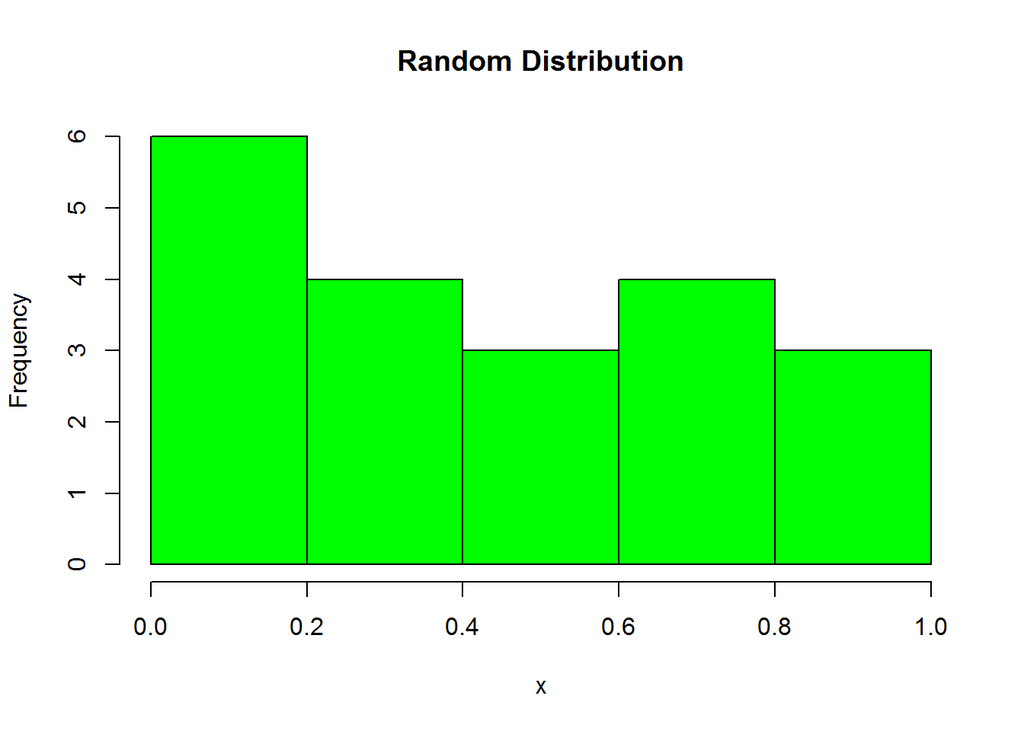

```r
hist(x, col='green', main ="Random Distribution")
```

- As expected, there is no normal distribution here.